# Statistical Computing Final

Hakan Karaotcu

2023-06-13

```r
#Import Packages
library(ggplot2)
library(MASS)
library(car)
library(stats)
library(multcomp)
library(dplyr)
library(tidyr)
library(car)
library(multcomp)
library(gmodels)
```

### **1. (3p) Data:**

Please find your original dataset or datasets; and describe your data in the first step.

#### **Answer:**

My data is about sales of video games. Columns Count: 16 Rows Count: 2009

###### **Columns:**

- Name: This column contains the names of the game titles
- Platform: This column specifies the gaming platform on which the game was released (e.g., Wii, NES, DS).
- Year_of_Release: This column denotes the year in which game was released.
- Genre: This column represents the genre of each game (e.g., Sports, Platform, Racing).
- Publisher: This column indicates the publishes of each game.
- NA_Sales: This column represents the sales in North America for each game in millions of units.
- EU_Sales: This column represents the sales in Europe for each game in millions of units.
- JP_Sales: This column represents the sales in Japan for each game in millions of units.
- Other_Sales: This column represents the sales in the rest of world (excluding North America, Europe, and Japan) for each game in millions of units.
- Global_Sales: This column represents the global sales for each game in millions of units
- Critic_Score: Represents the aggregated score given by game critics.
- Critic_Count: Denotes the number of critics who provided a score.
- User_Score: Represents the aggregated user score.
- User_Count: Denotes the number of users who provided a score.

```r
data <- read.csv("Video_Games_Sales.csv")
head(data)
```

```
##                       Name Platform Year_of_Release        Genre Publisher
## 1               Wii Sports      Wii            2006       Sports  Nintendo
## 2        Super Mario Bros.      NES            1985     Platform  Nintendo
## 3           Mario Kart Wii      Wii            2008       Racing  Nintendo
## 4        Wii Sports Resort      Wii            2009       Sports  Nintendo
## 5 Pokemon Red/Pokemon Blue       GB            1996 Role-Playing  Nintendo
## 6                   Tetris       GB            1989       Puzzle  Nintendo
##   NA_Sales EU_Sales JP_Sales Other_Sales Global_Sales Critic_Score Critic_Count
## 1    41.36    28.96     3.77        8.45        82.53           76           51
## 2    29.08     3.58     6.81        0.77        40.24           NA           NA
## 3    15.68    12.76     3.79        3.29        35.52           82           73
## 4    15.61    10.93     3.28        2.95        32.77           80           73
## 5    11.27     8.89    10.22        1.00        31.37           NA           NA
## 6    23.20     2.26     4.22        0.58        30.26           NA           NA
##   User_Score User_Count Developer Rating
## 1          8        322  Nintendo      E
## 2                    NA
## 3        8.3        709  Nintendo      E
## 4          8        192  Nintendo      E
## 5                    NA
## 6                    NA
```

### **2. (3p) Exploratory and descriptive data analysis:**

Use “Exploratory and descriptive data analysis”. Talk about your categorical and quantitative data or your ordinal variables etc. Write down your comments.

#### **Answer:**

###### **Categorical Variables:**

- Name: Each entry represents a unique game. It is a categorical data with textual data.
- Platform: It is a categorical variable indicating the platform of each game.
- Genre: It is a categorical variable categorizing games based on their genre:
- Publisher: It is a categorical variable representing different publishing companies.
- Developer: Indicates the developer of the game (e.g., Nintendo, Rockstar North).
- Rating: Reperesents the rating of the game (e.g., E,M).

###### **Ordinal Variables:**

- Year_of_Release: It is an ordinal variable, as the years have a natural order, but the differences between years may not be uniform.

###### **Quantitative Variables:**

- NA_Sales: It is a quantitative variable measuring the sales performance in a specific region.
- EU_Sales: It is a quantitative variable measuring the sales performance in a specific region.
- JP_Sales: It is a quantitative variable measuring the sales performance in a specific region.
- Other_Sales: It is a quantitative variable measuring the sales performance in other regions.
- Global_Sales: It is a quantitative variable measuring the overall sales performance worldwive.
- Critic_Score
- Critic_Count
- User_Score
- User_Count

### **3. (3p) Data Visualization:**

Use at least 4 useful, meaningful and different “data visualization techniques” which will help you understand your data further (distribution, outliers, variability, etc). Use 2 of the visualizations to compare two groups (like female/male; smoker/non-smoker etc).

#### **Answer:**

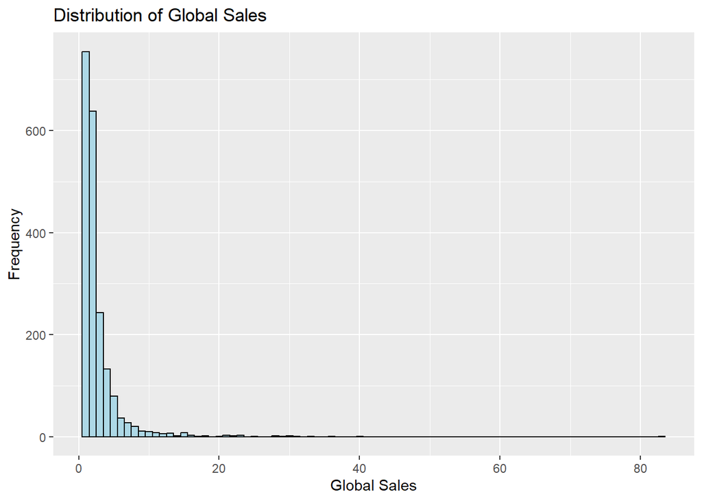

```r
# Histogram of Global Sales:
ggplot(data, aes(x = Global_Sales)) +
  geom_histogram(binwidth = 1, fill = "lightblue", color = "black") +
  labs(x = "Global Sales", y = "Frequency", title = "Distribution of Global Sales")
```

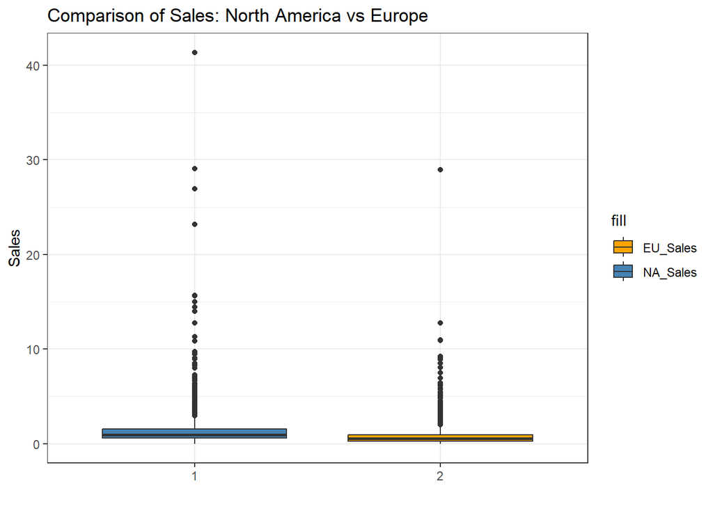

```r
# Box plot of Sales comparison between North America and Europe:
ggplot(data, aes(x = factor(1), y = NA_Sales, fill = "NA_Sales")) +
  geom_boxplot() + geom_boxplot(aes(x = factor(2), y = EU_Sales, fill = "EU_Sales")) +
  labs(x = "", y = "Sales", title = "Comparison of Sales: North America vs Europe") +
  scale_fill_manual(values = c("NA_Sales" = "steelblue", "EU_Sales" = "orange")) +
  theme_bw()
```

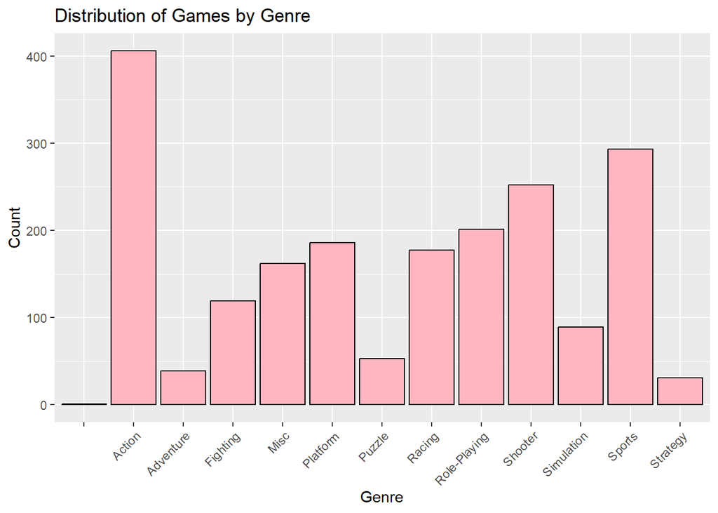

```r
# Bar plot of Genre:
ggplot(data, aes(x = Genre)) +
  geom_bar(fill = "lightpink", color = "black") +
  labs(x = "Genre", y = "Count", title = "Distribution of Games by Genre") +
  theme(axis.text.x = element_text(angle = 45, hjust = 1))
```

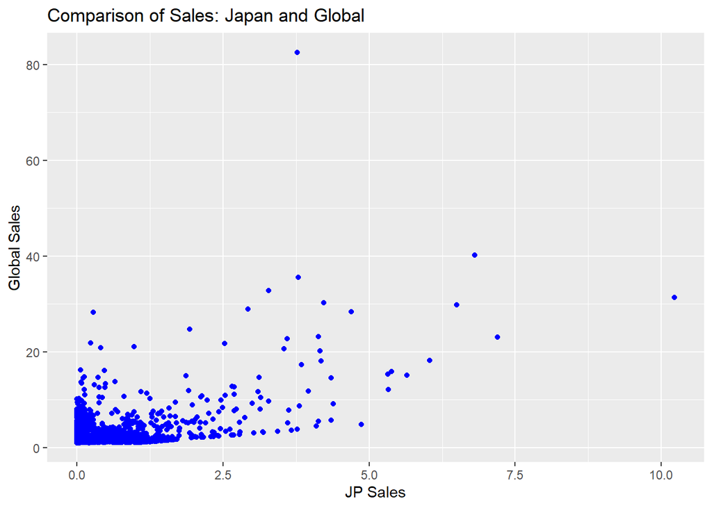

```r
# Scatter plot of Sales comparison between Japan and Global:
ggplot(data, aes(x = JP_Sales, y = Global_Sales)) + geom_point(color = "blue") +
  labs(x = "JP Sales", y = "Global Sales", title = "Comparison of Sales: Japan and Global")
```

### **4. (3p) Confidence Intervals:**

Build ‘2 Confidence Intervals’ step by step: Calculate the mean, then standard error, and then the CI. Make “clear comments” about your findings.

#### **Answer:**

```r
# Calculate the mean of Global Sales
mean_global_sales <- mean(data$Global_Sales)
mean_global_sales
```

```
## [1] 2.809766
```

```r
# A mean value of 2.809766 suggests that, on average, the Global Sales of video games in the sample is approximately 2.81 million units.

# Calculate the standard deviation of Global Sales
sd_global_sales <- sd(data$Global_Sales)

# Calculate the standard error of Global Sales
n <- length(data$Global_Sales)
se_global_sales <- sd_global_sales / sqrt(n)
se_global_sales
```

```
## [1] 0.08248244
```

```r
# A standard error of 0.08248244 suggests that the sample means of Global Sales are relatively tightly clustered around the population mean, providing a reasonably precise estimate of the true average Global Sales.

# Set the desired confidence level (e.g., 95%)
confidence_level <- 0.95

# Calculate the critical value based on the desired confidence level
critical_value <- qnorm((1 + confidence_level) / 2)

# Calculate the lower and upper bounds of the confidence interval
ci_lower <- mean_global_sales - (critical_value * se_global_sales)
ci_upper <- mean_global_sales + (critical_value * se_global_sales)

ci_lower
```

```
## [1] 2.648103
```

```r
ci_upper
```

```
## [1] 2.971429
```

```r
# Based on the given data and assuming a normal distribution, we estimate that the average Global Sales of video games, with a 95% confidence level, lies between approximately 2.65 million and 2.97 million units.
# This confidence interval provides a range of plausible values for the population mean. It suggests that, on average, the Global Sales of video games are expected to be within this range with a high degree of confidence.
```

### **5. (3p) Transformation:**

Implement one transformation (log transformation, Box-Cok transformation, etc) for one of your quantitative variables, which is not normally distributed; but will be normal or more normal, after the transformation.

#### **Answer:**

Applying log transformation to “NA_Sales” variable:

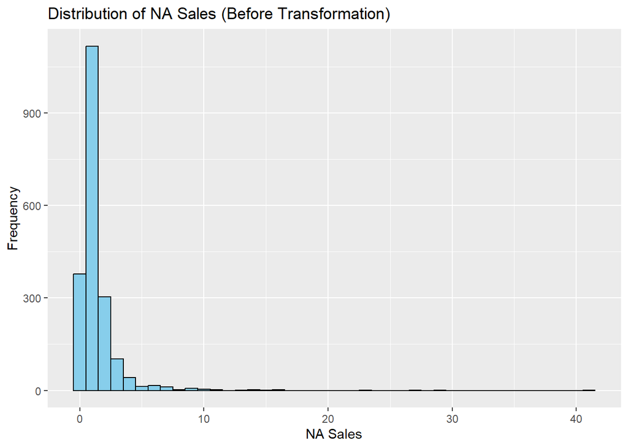

```r
na_sales <- data$NA_Sales
ggplot(data, aes(x = NA_Sales)) +
  geom_histogram(binwidth = 1, fill = "skyblue", color = "black") +
  labs(title = "Distribution of NA Sales (Before Transformation)", x = "NA Sales", y = "Frequency")
```

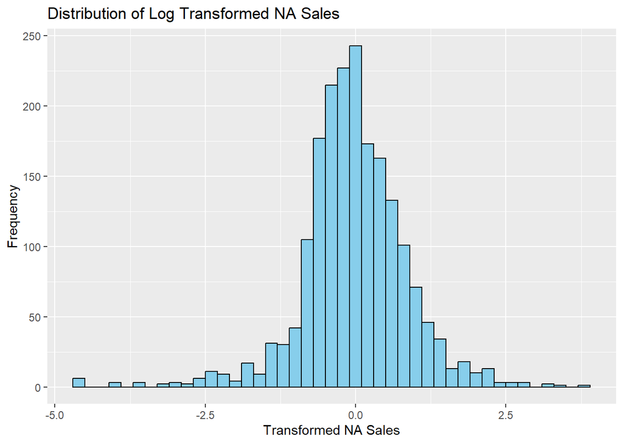

```r
# Apply log transformation to "NA_Sales" variable
transformed_sales <- log(na_sales)

# "NA_Sales" variable after transformation
ggplot(data.frame(transformed_sales), aes(x = transformed_sales)) +
  geom_histogram(binwidth = 0.2, fill = "skyblue", color = "black") +
  labs(title = "Distribution of Log Transformed NA Sales", x = "Transformed NA Sales", y = "Frequency")
```

### **6. (2p every item if not indicated) t-test (Welch t-test or Wilcoxon rank-sum test or Paired t-test)**

Implement a single t-test for one of your “normally or not-normally distributed” variable:

**a. Aim:** In words, what is your objective here?

#### **Answer:**

The objective of performing a Welch t-test for the “Global_Sales” variable between the Wii and X360 platforms is to determine if there is a significant difference in the mean global sales between these two platforms.

**b. Hypothesis and level of significance:** Write your hypothesis in scientific form and determine the level of singnificance.

#### **Answer:**

- Hypothesis (H0): There is no significant difference in the mean global sales between the Wii and X360 platforms.
- Alternative Hypothesis (H1): There is a significant difference in the mean global sales between the Wii and X360 platforms.
- Level of Significance: We used a significance level of α = 0.05, which is commonly used in hypothesis testing.

**c. Assumption Check (4p):** Is your data independent or dependent? Tell why you chose this test. Check the required assumptions statistically and “comment on each of them is a must!”.

#### **Answer:**

The data for the Global Sales of the Wii and X360 platforms are independent because they represent different platforms and are not related or dependent on each other.

The reason for choosing the Welch t-test is that it is suitable for comparing the means of two independent groups when the assumption of equal variances is violated or unknown.

###### **Required Assumptions:**

```r
# Subset the data
wii_sales <- data$Global_Sales[data$Platform == "Wii"]
x360_sales <- data$Global_Sales[data$Platform == "X360"]

# Shapiro-Wilk test for normality
shapiro.test(wii_sales)
```

```
##
##  Shapiro-Wilk normality test
##
## data:  wii_sales
## W = 0.35024, p-value < 2.2e-16
```

```r
shapiro.test(x360_sales)
```

```
##
##  Shapiro-Wilk normality test
##
## data:  x360_sales
## W = 0.61601, p-value < 2.2e-16
```

```r
# W is a test statistic calculated by Shapiro-Wilk test for "Global Sales" data on Wii platform. The test statistic is used to evaluate the departure from normality. In this case, the test statistic is relatively low. The p-value is a measure of the evidence against the null hypothesis. It indicates the probability of observing the data if the null hypothesis (normality) is true. In this case, the p-value is extremely small, indicating strong evidence against the null hypothesis of normality. The same goes for the X360 platform.
# In summary, both the Wii and X360 platforms exhibit significant departures from the normal distribution based on the Shapiro-Wilk test. The low p-values suggest that the "Global_Sales" data for both platforms does not follow a normal distribution.
```

**d. Indicate “which test you choose” “for what reason”**

#### **Answer:**

I chose the Welch t-test because it is suitable for comparing the means of two independent groups when the equal variance assumption is violated or unknown. This test is robust and does not assume equal variance between groups.

```r
# Subset the data for Wii and X360 platforms
wii_sales <- data$Global_Sales[data$Platform == "Wii"]
x360_sales <- data$Global_Sales[data$Platform == "X360"]

# Perform Welch t-test
t_test <- t.test(wii_sales, x360_sales, alternative = "two.sided", var.equal = FALSE)

# The "alternative" parameter is set to "two.sided" to detect any difference in means, and the "var.equal" parameter is set to "FALSE" to account for potentially unequal variances between the two group.
```

**e. Result:** Give the output of the test and write down the result (ex: since p value is less /greater than alpha, I reject/not reject the null hypothesis).

#### **Answer:**

```r
# Print the results
cat("Welch Two-Sample t-test\n")
```

```
## Welch Two-Sample t-test
```

```r
cat("Null hypothesis: The means of the two groups are equal\n")
```

```
## Null hypothesis: The means of the two groups are equal
```

```r
cat("Alternative hypothesis: The means of the two groups are not equal\n")
```

```
## Alternative hypothesis: The means of the two groups are not equal
```

```r
cat("Group 1: Wii\n")
```

```
## Group 1: Wii
```

```r
cat("Group 2: X360\n")
```

```
## Group 2: X360
```

```r
cat("Wetch t-statistics:", t_test$statistic, "\n")
```

```
## Wetch t-statistics: 1.690743
```

```r
cat("Degrees of freedom:", t_test$parameter, "\n")
```

```
## Degrees of freedom: 166.6742
```

```r
cat("p_value:", t_test$p.value, "\n")
```

```
## p_value: 0.09275508
```

The results of the Welch t-test are as follows:

Welch t-statistics: 1.690743 Degrees of freedom: 166.6742 p-value: 0.09275508

The t-statistics of 1.690743 suggests that there is a moderate difference between the means of the two groups. The degrees of freedom indicate the precision of the estimate. The p-value of 0.09275508 is greater than 0.05(alpha), which means that we do not have enough evidence to reject the null hypothesis. There is not sufficient statistical evidence to conclude that there is a significant difference in the global sales between the Wii and X360 platforms.

**f. Conclusion (4p):** You got your result in item e. Write down the conclusion of your result, in such a way that, the reader who doesn’t know any statistics can understand your findings.

#### **Answer:**

After conducting a Welch t-test to compare the global sales of the Wii and X360 platforms, the analysis showed that there is not enough evidence to suggest a significant difference between the two platforms. This means that, based on the available data, we cannot conclude that one platform has significantly higher global sales than the other. Therefore, there is no clear indication that one platform outperforms the other in terms of global sales.

**g. What can be Type-1 and Type-2 error here? Not definition! Tell these situations in terms of your data (4p)**

#### **Answer:**

Type I Error: In the context of our data, a Type I error would occur if we concluded that there is a significant difference in global sales between the Wii and X360 platforms, when in reality there is no true difference. In other words, we mistakenly claim that one platform has higher global sales when there is no statistical evidence to support this conclusion. Type II Error: In our data, a Type II error would happen if we fail to detect a significant difference in global sales between the Wii and X360 platforms, even though there is a true difference. This means that we erroneously conclude that the platforms have similar global sales when, in fact, one platform may have higher global sales than the other.

### **7. (2p every item if not indicated) Fisher’s exact test for count data**

**a. Aim:** In words, what is your objective? Provide the contingency table here.

#### **Answer:**

Our aim is to determine whether there is a statistically significant relationship between two variables, such as genre and publisher, using count data.

```r
# Since the dataset was so large, I had to shrink it to be able to run the Fishers exact test. (something like matrix 20 x 80 was going on)
subset_data <- subset(data, Publisher == "Activision" | Publisher == "Nintendo")
subset_data <- subset(subset_data, Genre == "Sports" | Genre == "Shooter")
contingency_table <- table(subset_data$Publisher, subset_data$Genre)
contingency_table
```

```
##
##              Shooter Sports
##   Activision      59     14
##   Nintendo        14     27
```

**b. Hypothesis and level of significance:** Write your hypothesis in scientific form and determine the level of singnificance.

#### **Answer:**

- Null Hypothesis (H0): There is no association between the Genre and Publisher variables in the dataset.
- Alternative Hypothesis (H1): There is an association between the Genre and Publisher variables in the dataset.
- Level of Significance: We used a significance level of α = 0.05, which is commonly used in hypothesis testing.

**c. Result:** Give the output of the test and write down the result (ex: since p value is less /greater than alpha, I reject/not reject the null hypothesis).

#### **Answer:**

```r
# Perform Fishers exact test
fisher_result <- fisher.test(contingency_table)
fisher_result
```

```
##
##  Fisher's Exact Test for Count Data
##
## data:  contingency_table
## p-value = 1.42e-06
## alternative hypothesis: true odds ratio is not equal to 1
## 95 percent confidence interval:
##   3.140332 21.295725
## sample estimates:
## odds ratio
##   7.943226
```

In conclusion, a p-value of 1.42e-06 provides strong evidence to reject the null hypothesis and suggests that there is a significant relationship between genre and publisher in out dataset.

**d. Conclusion (4p):** You got your result in item c. Write down the conclusion of your result, in such a way that, the reader who doesn’t know any statistics can understand your findings.

#### **Answer:**

The analysis using Fishers exact test revealed a highly significant relationship between the genre and publisher of video games in the dataset. This means that the choice of publisher is not independent of the genre of the game. In other words, certain genres tend to be associated with specific publishers more frequently than what would be expected by chance alone.

### **8. (2p every item if not indicated) ANOVA and Tukey Test**

**a. Aim** In words, what is your objective here?

#### **Answer:**

The objective of performing ANOVA (analysis of variance) and Tukeys test is to determine if there are significant differences in the global sales of video games across different genres.

**b. Hypothesis and level of significance:** Choose more than 2 (≥3) groups to compare! Write your hypothesis in scientific form and determine the level of singnificance.

#### **Answer:**

- Null Hypothesis (H0): The mean global sales of video games are equal across multiple genres.
- Alternative Hypothesis (H1): The mean global sales of video games are not equal across multiple genres.
- Level of Significance: We used a significance level of α = 0.05, which is commonly used in hypothesis testing.

**c. Assumption Check:** Check the required assumptions statistically. “comment on each of them is a must!”

#### **Answer:**

###### **Required Assumption:**

1. Independence: The observations within each group are assumed to be independent of each other. This assumption is typically met if the data is collected through random sampling or experimental design.
2. Normality: The distribution of the dependent variable (global sales) within each group should be approximately normally distributed. Violations of normality can affect the accuracy and reliability of the results.
3. Homogeneity of variances: The variances of the dependent variable should be equal across all groups. Violations of this assumption can affect the validity of the F-test in ANOVA.

**d. Result of ANOVA:** Give the output of the test and write down the result (ex:since p value is less than alpha, I reject the null hypothesis)

#### **Answer:**

```r
# Perform ANOVA
model <- aov(Global_Sales ~ Genre, data = data)
anova_results <- summary(model)
anova_results
```

```
##               Df Sum Sq Mean Sq F value Pr(>F)
## Genre         12    231   19.23   1.411  0.153
## Residuals   1996  27214   13.63
```

A p-value of 0.15 indicates that there is a 15% chance of observing data or more extreme results if the mean of the groups are indeed equal. However, since the p-value is greater than the significance level, it is not statistically significant and we fail to reject the null hypothesis.

**e. Conclusion of ANOVA (4p)** You got your result in item d. Write down the conclusion of your result, in such a way that, the reader who doesn’t know any statistics can understand your findings.

#### **Answer:**

The data does not provide strong support for the idea that the means of the groups are significantly different. This suggests that any observed differences in the data could be due to random variation rather than actual meaningful distinctions between the groups.

**f. Result of Tukey:** Give the output of the test and write down the result (ex: since p value is less /greater than alpha, I reject/not reject the null hypothesis)

#### **Answer:**

```r
# Perform Tukeys test for multiple comparisons
tukey_results <- TukeyHSD(model)
tukey_results
```

```
##   Tukey multiple comparisons of means
##     95% family-wise confidence level
##
## Fit: aov(formula = Global_Sales ~ Genre, data = data)
##
## $Genre
##                                diff         lwr        upr     p adj
## Action-                  0.18911330 -12.0731882 12.4514148 1.0000000
## Adventure-              -0.09974359 -12.5029935 12.3035063 1.0000000
## Fighting-               -0.14058824 -12.4391675 12.1579910 1.0000000
## Misc-                    0.48333333 -11.8016365 12.7683032 1.0000000
## Platform-                1.07489247 -11.2052140 13.3549989 1.0000000
## Puzzle-                  0.52433962 -11.8378883 12.8865675 1.0000000
## Racing-                  0.32242938 -11.9593465 12.6042053 1.0000000
## Role-Playing-            0.79467662 -11.4829793 13.0723325 1.0000000
## Shooter-                 0.71174603 -11.5597579 12.9832500 1.0000000
## Simulation-              0.11134831 -12.2044921 12.4271887 1.0000000
## Sports-                  0.28505119 -11.9830587 12.5531610 1.0000000
## Strategy-               -0.27290323 -12.7160993 12.1702928 1.0000000
## Adventure-Action        -0.28885689  -2.3420154  1.7643017 0.9999997
## Fighting-Action         -0.32970154  -1.6063783  0.9469752 0.9997414
## Misc-Action              0.29422003  -0.8439089  1.4323489 0.9997387
## Platform-Action          0.88577917  -0.1985950  1.9701533 0.2481740
## Puzzle-Action            0.33522632  -1.4534971  2.1239497 0.9999919
## Racing-Action            0.13331608  -0.9698031  1.2364352 0.9999999
## Role-Playing-Action      0.60556332  -0.4506973  1.6618240 0.7947052
## Shooter-Action           0.52263273  -0.4595391  1.5048045 0.8668204
## Simulation-Action       -0.07776499  -1.5112144  1.3556845 1.0000000
## Sports-Action            0.09593789  -0.8428761  1.0347519 1.0000000
## Strategy-Action         -0.46201653  -2.7441164  1.8200834 0.9999809
## Fighting-Adventure      -0.04084465  -2.3005955  2.2189062 1.0000000
## Misc-Adventure           0.58307692  -1.6013927  2.7675466 0.9996364
## Platform-Adventure       1.17463606  -0.9823150  3.3315871 0.8468144
## Puzzle-Adventure         0.62408321  -1.9597322  3.2078986 0.9998717
## Racing-Adventure         0.42217297  -1.7442624  2.5886084 0.9999875
## Role-Playing-Adventure   0.89442021  -1.2485350  3.0373754 0.9766406
## Shooter-Adventure        0.81148962  -1.2959334  2.9189127 0.9880821
## Simulation-Adventure     0.21109190  -2.1407898  2.5629736 1.0000000
## Sports-Adventure         0.38479478  -1.7027737  2.4723633 0.9999932
## Strategy-Adventure      -0.17315964  -3.1201158  2.7737965 1.0000000
```

[output cut: 30 more lines]

```
## Role-Playing-Racing      0.47224724  -0.7901587  1.7346532 0.9907308
## Shooter-Racing           0.38931665  -0.8117844  1.5904177 0.9975059
## Simulation-Racing       -0.21108106  -1.8025457  1.3803835 0.9999998
## Sports-Racing           -0.03737818  -1.2032916  1.1285352 1.0000000
## Strategy-Racing         -0.59533260  -2.9798582  1.7891930 0.9998182
## Shooter-Role-Playing    -0.08293059  -1.2411440  1.0752829 1.0000000
## Simulation-Role-Playing -0.68332830  -2.2426789  0.8760223 0.9656450
## Sports-Role-Playing     -0.50962542  -1.6313066  0.6120558 0.9547662
## Strategy-Role-Playing   -1.06757984  -3.4307931  1.2956334 0.9566652
## Simulation-Shooter      -0.60039772  -2.1105464  0.9097510 0.9843565
## Sports-Shooter          -0.42669484  -1.4789037  0.6255141 0.9815476
## Strategy-Shooter        -0.98464926  -3.3156902  1.3463917 0.9742766
## Sports-Simulation        0.17370288  -1.3086127  1.6560184 1.0000000
## Strategy-Simulation     -0.38425154  -2.9384379  2.1699348 0.9999993
## Strategy-Sports         -0.55795442  -2.8710610  1.7551522 0.9998735
```

The highest p-value (1.0000000) represents the largest level of p-value, indicating no significant difference between the groups being compared. A p-value of 1.0000000 suggests that there is not enough evidence to reject the null hypothesis of no difference between the groups.

All other p-values falling between the lowest and highest values represent the levels of statistical significance for the remaining pairwise comparisons. These p-values indicate the strength of evidence for a significant difference between the corresponding groups.

### **9. (2p every item) Multiple Linear Regression**

**a. Aim** In words, what is your objective here? Not definition, talk about your own aim/problem.

#### **Answers:**

The objective is explore the relationship between the video game sales (dependent variable) and various factors such as critic score, user score, critic count, and user count (independent variables). By fitting a regression model, we aim to understand how these independent variables collectively influence the global sales of video games.

**b. Regression Equation:** Multiple linear regression (MLR) is a statistical technique that uses several explanatory variables to predict the outcome of a response variable. Which ones are your explanatory variables and which one is your response variable? Write down the “statistical/mathematical equation” of your regression function using those variables and the parameters.

#### **Answer:**

The explanatory variables are the critic score, user score, critic count, and user count. These variables are used to predict the response variable, which is the global sales of video games.

The statistical/mathematical equation of the regression function:

Global_Sales = β0 + β1 * Critic_Score + β2 * User_Score + β3 * Critic_Count + β4 * User_Count + ε

**c. Hypothesis and level of significance:** Write your hypothesis in scientific form and determine the level of singnificance.

#### **Answer:**

- Null Hypothesis (H0): There is no significant linear relationship between the critic score, user score, critic count, user count, and global sales of video games.
- Alternative Hypothesis (H1): There is a significant linear relationship between the critic score, user score, critic count, user count, and global sales of video games.
- Level of Significance: We used a significance level of α = 0.05, which is commonly used in hypothesis testing.

**d. Find the Best Model:** Use step function and find the best model, describe the reason which makes it the best one.

#### **Answer:**

```r
full_model <- lm(Global_Sales ~ Critic_Score + User_Score + Critic_Count + User_Count, data = data)
# Use step function to select the best model
best_model <- step(full_model, direction = "both")
```

```
## Start:  AIC=3490.6
## Global_Sales ~ Critic_Score + User_Score + Critic_Count + User_Count
##
##                Df Sum of Sq   RSS    AIC
## - User_Score   69    642.26 17884 3399.8
## <none>                      17242 3490.6
## - Critic_Count  1    102.93 17345 3496.3
## - Critic_Score  1    110.37 17352 3496.8
## - User_Count    1    259.93 17502 3507.9
##
## Step:  AIC=3399.77
## Global_Sales ~ Critic_Score + Critic_Count + User_Count
##
##                Df Sum of Sq   RSS    AIC
## <none>                      17884 3399.8
## - Critic_Count  1    102.67 17987 3405.2
## - Critic_Score  1    150.40 18035 3408.6
## - User_Count    1    310.49 18195 3420.0
## + User_Score   69    642.26 17242 3490.6
```

Best model has the lowest AIC value of 3399.8, indicating a better trade-off between model fit and complexity compared to the other models evaluated.

**e. Assumption Check (4p):** Check the required assumptions statistically, “comment on each of them is a must!”

#### **Answer:**

###### **Required Assumption:**

1. Linearity: The relationships between the predictors (Critic_Score, Critic_Count, User_Count) and the response variable (Global_Sales) should be linear.
2. Independence: The observations in the Video_Games dataset should be independent of each other.
3. Homoscedasticity: The variability of the residuals (the differences between the actual and predicted values) should be constant across all levels of the predictors.
4. Normality: The residuals should follow a roughly normal distribution.
5. No multicollinearity: The predictor variables (Critic_Score, Critic_Count, User_Count) should not be highly correlated with each other.

**f. Result** Give the output of the best model and write down the result.

#### **Answer:**

```r
best_model
```

```
##
## Call:
## lm(formula = Global_Sales ~ Critic_Score + Critic_Count + User_Count,
##     data = data)
##
## Coefficients:
##  (Intercept)  Critic_Score  Critic_Count    User_Count
##   -0.6631365     0.0338934     0.0135022     0.0005444
```

The regression equation:

Global_Sales = -0.6631365 + 0.0338934 * Critic_Score + 0.0135022 * Critic_Count + 0.0005444 * User_Count

The intercept term (-0.6631365) represents the estimated Global_Sales when all the predictor variables (Critic_Score, Critic_Count, User_Count) are zero. The coefficient for Critic_Score (0.0338934) suggests that for every unit increase in Critic_Score, the Global_Sales are expected to increase by 0.0338934 units, assuming all other variables remain constant. The coefficient for Critic_Count (0.0135022) suggests that for every unit increase in Critic_Count, the Global_Sales are expected to increase by 0.0135022 units, holding all other variables constant. The coefficient for User_Count (0.0005444) suggests that for every unit increase in User_Count, the Global_Sales are expected to increase by 0.0005444 units, assuming all other variables remain constant.

**g. Conclusion (4p):** You got your result in item f. Write down the conclusion of your result, in such a way that, the reader who doesn’t know any statistics can understand your findings.

#### **Answer:**

The sales of video games (Global_Sales) can be predicted by considering three factors: Critic_Score, Critic_Count, and User_Count. The model suggests that these variables have a significant impact on the global sales of video games.

Critic_Score: As the overall score given by critics increases, the global sales of video games tend to increase. This indicates that positive reviews and higher ratings from critics can positively influence the sales performance of video games.

Critic_Count: The number of critics reviewing a video game also plays a role in its global sales. As the count of critics reviewing a game increases, the global sales are expected to increase as well. This suggests that more exposure and attention from critics can contribute to higher sales.

User_Count: The number of users or players of a video game is another factor influencing global sales. As the user count increases, the global sales of video games are expected to show a slight increase. This implies that a larger user base or popularity among gamers can have a positive impact on sales.